# Trends in Food Choices

**Question:** Is GPA related to student income, the father’s educational level, or the student’s perception of what an ideal diet is?

**Introduction:** We are working with the `Food choices` dataset, concerning the eating habits of 126 students at Mercyhurst University. A detailed data dictionary for this dataset is available [here.](https://wilkelab.org/DSC385/datasets/food_codebook.pdf). The dataset has 61 features of varying types; some are quantitative, some categorical, and others are text survey responses. Our study focuses on the categorical features `income`, `father_education`, and `ideal_diet_coded`, as well as the character response variable `GPA`. To address the question, we look for relationships between `GPA` and each of the three categorical features. We note that the dataset includes a column `ideal_diet` that could also be used to answer the question. As `ideal_diet` consists of survey responses that would require textual analysis and grouping, we utilize `ideal_diet_coded` which separates the survey responses into eight categories.

**Approach:** Our approach is to create three plots comparing the grade-point-average distributions of students according to their (1) income, (2) father’s education, and (3) ideal diet. In each case, we create a ridgeline plot using geom_density_ridges(). When we consider the data according to these categories, we find that we can form groups with great disparities in total count. By utilizing, geom_density_ridges(), we are able to observe trends in the relative proportions of students at various GPA intervals.

Two of the categories–`income` and `father_education`–have inherent ordering. We refactor `income` to range from low to high and we refactor `father_education` to range from less education to more education. The category `ideal_diet_coded` has no inherent order. When rendering the plot, we order the `ideal_diet_coded` categories (1-8) by median grade point average. To clean the data, we first remove the few text characters in the GPA column that cause `R` to recognize it as a character vector, and we then convert the column to numeric. We remove six rows with `NA` values: one each from the `income` and `father_education` columns and four from the `GPA` column. Using case_when(), we recode each of the columns to have more descriptive language associated with their respective categories.

**Analysis:** We begin our analysis by summarizing each of the four columns. `GPA` ranges from 2.2 to 4, with a median of 3.5. We note that each of the three categorical columns have categories with very few observations. For example. the ‘Less than high school’ category of `father_education` has only four entries. As our visualizations will utilize densities, we would prefer to avoid categories with such small sample sizes. Therefore, as we make each plot, we will make adjustments to make sure each category has sufficient numbers of observations.

First, we plot the grade-point-average distributions according to income. Here, we combine the low-observation categories at the lowest end of the range, which have only six and seven observations, respectively.

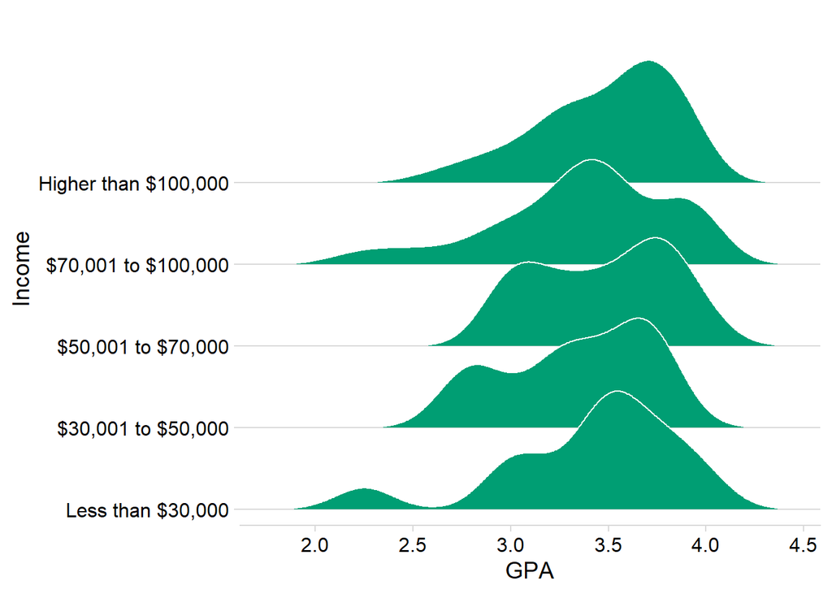

Next, we plot the grade-point-average distributions according to father’s education. Here, we combine the category ‘Less than high school’, which has only four categories, with ‘High school diploma’.

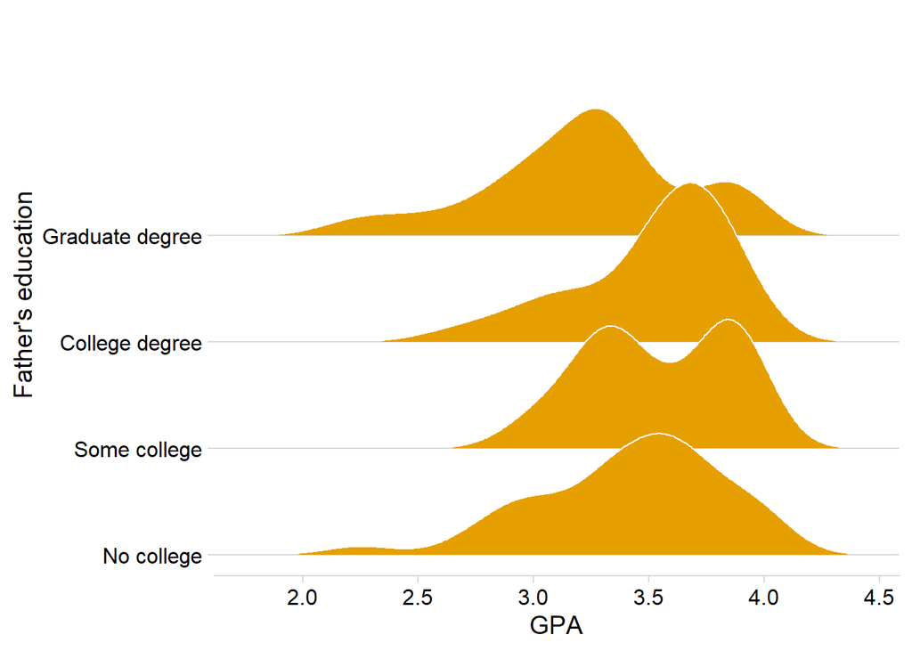

And lastly we plot GPA distribution according to ideal diet. Here, we remove the ‘Unclear’ category, as it only has three observations and appears unlikely to yield useful insights.

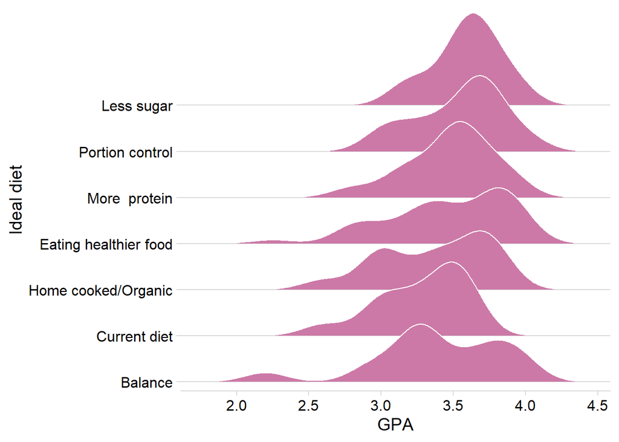

The second plot suggests an interesting dynamic in the relationship between GPA and father’s education. There does not appear to be any strong correlation except for students with the most highly education fathers. The GPA distribution of these students is clearly lower in terms of mean and range. Statistical analysis may help identify the factors underlying this trend.

Relationships between GPA and ideal diet are not immediately obvious based on the density ridges in the third plot. Each distribution has one or two modes around 3.5 and it is difficult to find a great deal of significance based on the visualization. However, when we consider that the plots are ordered by median GPA, we get a hint of an interesting dynamic that may be at play. The groups with the highest median–‘Less sugar’, ‘Portion control’, and ‘More protein’–have very specific dietary strategies in mind. Those with the lowest median GPA–‘Balance’, ‘Current diet’, and ‘Home cooked-Organic’–have strategies that are more ambiguous.